# R Notebook

```r
library(CodeClanData)
```

1. Load in the libraries you need, and look at the backpack data. Take note of variable names and dimensions.

| backpack_weight | body_weight | ratio | back_problems | major | year | sex | status | units |
| --- | --- | --- | --- | --- | --- | --- | --- | --- |
| 9 | 125 | 0.0720000 | 1 | Bio | 3 | Female | U | 13 |
| 8 | 195 | 0.0410256 | 0 | Philosophy | 5 | Male | U | 12 |
| 10 | 120 | 0.0833333 | 1 | GRC | 4 | Female | U | 14 |
| 6 | 155 | 0.0387097 | 0 | CSC | 6 | Male | G | 0 |
| 8 | 180 | 0.0444444 | 0 | EE | 2 | Female | U | 14 |
| 5 | 240 | 0.0208333 | 0 | History | 0 | Male | G | 0 |
| 8 | 170 | 0.0470588 | 0 | CM | 3 | Male | U | 15 |
| 4 | 185 | 0.0216216 | 1 | ARCE | 5 | Female | U | 18 |
| 5 | 130 | 0.0384615 | 0 | Bio | 4 | Female | U | 14 |
| 2 | 120 | 0.0166667 | 0 | Bio | 5 | Female | U | 8 |

[output cut: 90 more lines]

2. What is the distribution of backpack weights that students are carrying? Choose an appropriate graph to show the distribution.

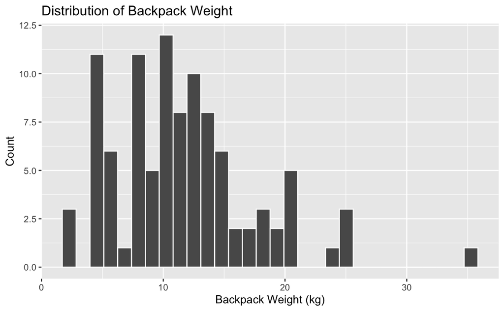

```r
backpack %>%
  ggplot() +
  aes(x = backpack_weight) +
  geom_histogram(colour = "white") +
  labs(x = "Backpack Weight (kg)",
       y = "Count",
       title = "Distribution of Backpack Weight")
```

- This shows that the majority of backpack weights are around 10kg.
3. Are there differences in backpack weight between sex?

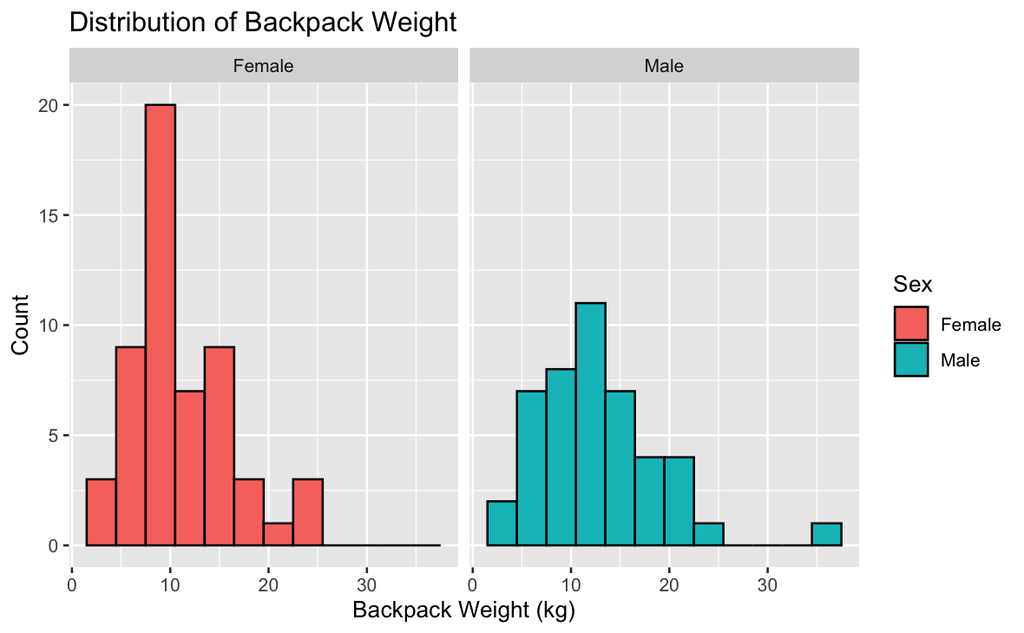

```r
backpack %>%
  ggplot() +
  aes(x = backpack_weight, fill = sex) +
  geom_histogram(position = "dodge",
                 binwidth = 3,
                 colour = "black") +
  facet_wrap(~ sex) +
  labs(x = "Backpack Weight (kg)",
       y = "Count",
       title = "Distribution of Backpack Weight",
       fill = "Sex")
```

- This shows that males carry slightly heavier backpacks than females.
4. What is the relationship between body weight and backpack weight?

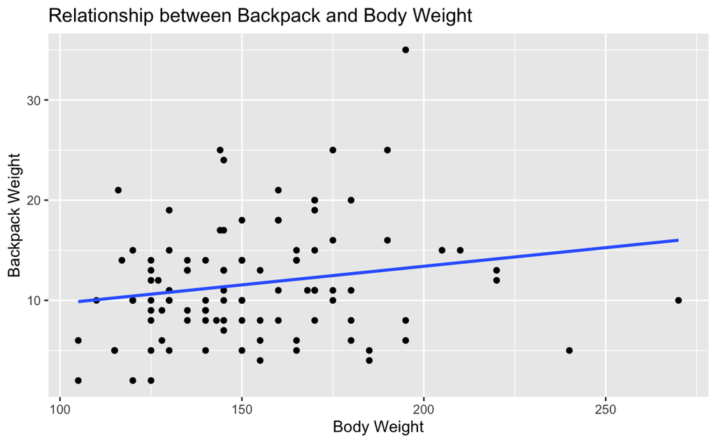

```r
backpack %>%
  ggplot() +
  aes(x = body_weight, y = backpack_weight) +
  geom_point() +
  geom_smooth(method = lm,
              se = FALSE) +
  labs(x = "Body Weight",
       y = "Backpack Weight",
       title = "Relationship between Backpack and Body Weight")
```

```r
NA
```

- This scatter plot shows a correlation between body weight and backpack weight.
5. Is this relationship different between men and women? Choose an appropriate plot and interpret your findings.

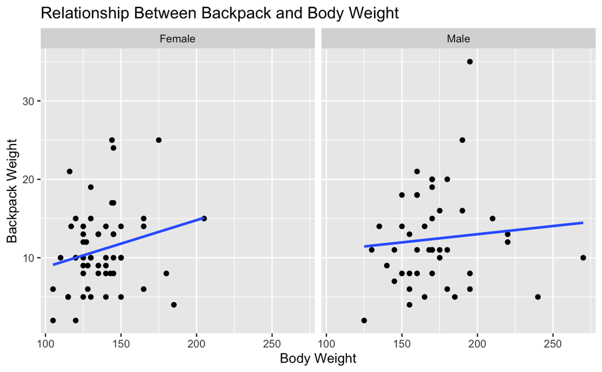

```r
backpack %>%
  ggplot() +
  aes(x = body_weight, y = backpack_weight) +
  geom_point() +
  geom_smooth(method = lm,
              se = FALSE) +
  facet_wrap(~ sex) +
  labs(x = "Body Weight",
       y = "Backpack Weight",
       title = "Relationship Between Backpack and Body Weight")
```

- Initially these plots show that there is a stronger correlation between body weight and backpack weight in females than in males. But if I change the limits to show the majority of people from each sex, with no extremes, it shows a very similar correlation. Meaning that the `sex` doesn’t matter too much, it’s more the `body_weight`.

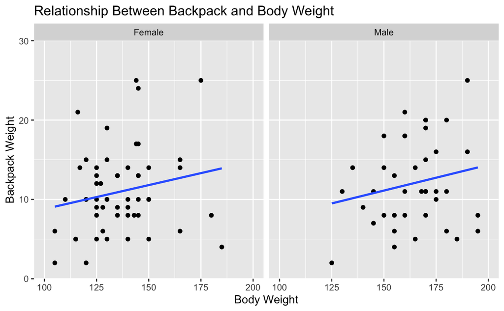

```r
backpack %>%
  ggplot() +
  aes(x = body_weight, y = backpack_weight) +
  geom_point() +
  geom_smooth(method = lm,
              se = FALSE) +
  facet_wrap(~ sex) +
    scale_y_continuous(expand = c(0,0),
                     limits = c(0, 30)) +
  scale_x_continuous(limits = c(100, 200)) +
  labs(x = "Body Weight",
       y = "Backpack Weight",
       title = "Relationship Between Backpack and Body Weight")
```

6. What proportion of students report back pain?

| backpack_weight | body_weight | ratio | back_problems | major | year | sex | status | units |
| --- | --- | --- | --- | --- | --- | --- | --- | --- |
| 9 | 125 | 0.0720000 | 1 | Bio | 3 | Female | U | 13 |
| 8 | 195 | 0.0410256 | 0 | Philosophy | 5 | Male | U | 12 |
| 10 | 120 | 0.0833333 | 1 | GRC | 4 | Female | U | 14 |
| 6 | 155 | 0.0387097 | 0 | CSC | 6 | Male | G | 0 |
| 8 | 180 | 0.0444444 | 0 | EE | 2 | Female | U | 14 |
| 5 | 240 | 0.0208333 | 0 | History | 0 | Male | G | 0 |
| 8 | 170 | 0.0470588 | 0 | CM | 3 | Male | U | 15 |
| 4 | 185 | 0.0216216 | 1 | ARCE | 5 | Female | U | 18 |
| 5 | 130 | 0.0384615 | 0 | Bio | 4 | Female | U | 14 |
| 2 | 120 | 0.0166667 | 0 | Bio | 5 | Female | U | 8 |

[output cut: 90 more lines]

- This shows that around 1/3 of students reported back pain
7. Is this proportion different between men and women?

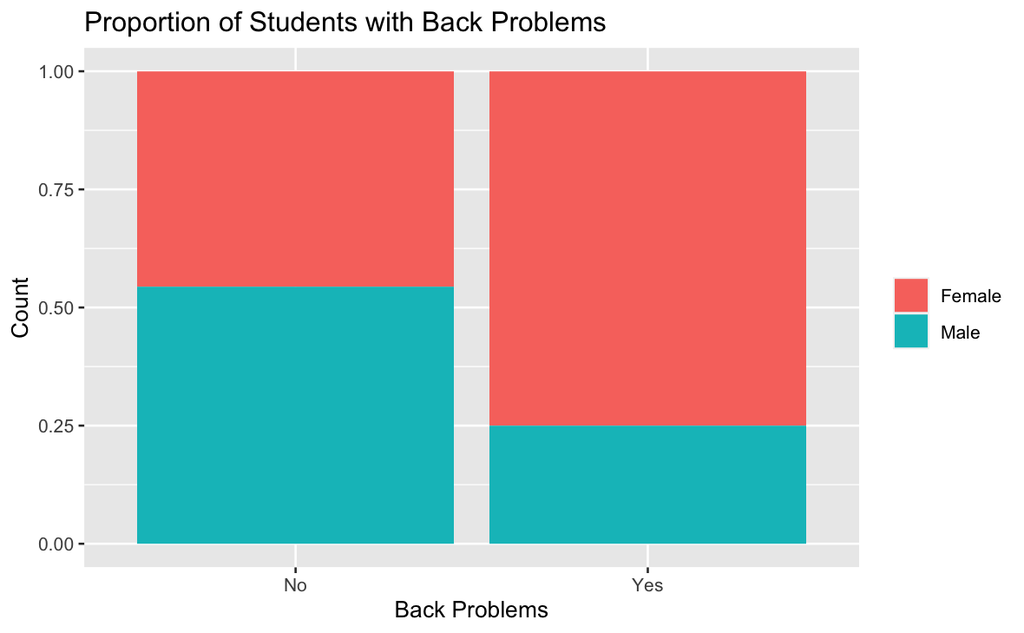

```r
back_pain <- backpack %>%
  mutate(back_problems = case_when(
    back_problems == 1 ~ "Yes",
    back_problems == 0 ~ "No"))

back_pain %>%
  ggplot() +
  aes(x = back_problems, fill = sex) +
  geom_bar(position = "fill") +
  labs(x = "Back Problems",
       y = "Count",
       title = "Proportion of Students with Back Problems",
       fill = NULL)
```

```r
backpack %>%
  group_by(sex) %>%
  summarise(count = n())
```

| sex | count |
| --- | --- |
| Female | 55 |
| Male | 45 |

- This shows that a higher proportion of females have reported back problems.
8. Now you’ve investigated your data separately, create plots to describe the relationship between backpack weight, body weight, gender and reported backpain.

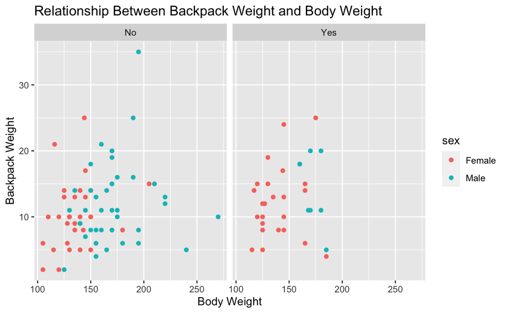

```r
back_pain %>%
  ggplot() +
  aes(x = body_weight, y = backpack_weight, colour = sex) +
  geom_point() +
  facet_wrap(~ back_problems) +
  labs(x = "Body Weight",
       y = "Backpack Weight",
       fill = NULL,
       title = "Relationship Between Backpack Weight and Body Weight")
```

- This shows that the majority of people reporting back pain are females in the 100 - 150kg weight range.